# Mise en oeuvre du module GPS/GPRS

## Présentation

La série SIM5218 est un module GSM / GPRS / EDGE quadri-bande supportant les protocoles HSPA et la technologie WCDMA. Il autorise un débit descendant (*download*) de 7.2Mbps et un débit montant (*upload*) de 5,76Mbps. Il intègre aussi un GPS.

[figure not shown]

Lien : [www.cooking-hacks.com](https://www.cooking-hacks.com/3g-gprs-shield-for-arduino-3g-gps-audio-video-kit)

[figure not shown]

Le module SIM5218 sera détecté comme un port série virtuel lorsqu’il est relié par une liaison USB. On le programmera à partir de commandes AT.

Lire : SIM5218_AT_command_manual.pdf

## Commandes AT

La firme Hayes, fabricant de modems, a développé un protocole pour la commande d’un modem externe à partir d’un ordinateur. Le protocole définit diverses commandes permettant par exemple :

- de composer un numéro de téléphone
- de commander le raccordement du modem à la ligne (l’équivalent de décrocher le téléphone)
- de connaître l’état de la ligne : tonalité d’invitation à transmettre, ligne occupée …
- de spécifier le type de transmission et le protocole de liaison à utiliser
- de régler le volume sonore du haut-parleur interne du modem
- d’envoyer les caractères transmis simultanément vers l’écran
- d’afficher certains renseignements concernant le modem
- de manipuler les registres internes du modem

Les commandes AT (ou Commandes Hayes) sont des commandes que l’on peut directement envoyer au modem, lorsque celui-ci est en mode Command.

Chaque commande est envoyée sous la forme d’une ligne de texte encodée en ASCII, terminée par le caractère ‘\r’ seul (code ASCII 0x13). Le modem retourne une réponse sous la forme d’une ou plusieurs lignes selon la commande envoyée, chaque ligne se terminant par les caractères ‘\r’ suivi de ‘\n’ (codes ASCII 0x13 et 0x10).

## Géolocalisation par GPS

Le module SIM5218 peut fournir une géolocalisation par commandes AT ou par phrases NMEA 0183.

### Notions de base

Le GPS (*Global Positioning System*) est un système de géolocalisation fonctionnant au niveau mondial et reposant sur l’exploitation de signaux radio émis par des satellites dédiés. Le GPS utilise le système géodésique WGS 84, auquel se réfèrent les coordonnées calculées grâce au système.

Lire : [Global Positioning System](https://fr.wikipedia.org/wiki/Global_Positioning_System) et [Récepteur GPS](https://fr.wikipedia.org/wiki/R%C3%A9cepteur_GPS)

Une personne munie d’un récepteur GPS peut ainsi se localiser et s’orienter sur terre, sur mer, dans l’air ou dans l’espace au voisinage proche de la Terre.

### La norme NMEA 0183

La norme **NMEA 0183** est une spécification pour la communication entre équipements marins, dont les équipements GPS. Elle est définie et contrôlée par la *National Marine Electronics Association* (NMEA), association américaine de fabricants d’appareils électroniques maritimes.

[figure not shown]

La norme 0183 utilise une simple communication série pour transmettre une “phrase” (*sentence*) à un ou plusieurs écoutants. Une trame NMEA utilise tous les caractères ASCII.

Exemple : *Waypoint Arrival Alarm*

```
$GPAAM,A,A,0.10,N,WPTNME*32
```

Il existe plus d’une trentaine de trames GPS différentes. Le type d’équipement est défini par les deux caractères qui suivent le `$`. Le type de trame est défini par les caractères suivants jusqu’à la virgule.

Par exemple :

```
$GPGGA,064036.289,4836.5375,N,00740.9373,E,1,04,3.2,200.2,M,,,,0000*0E
```

C’est une trame __GP__S de type **GGA**. La trame GGA est très courante car elle fait partie de celles qui sont utilisées pour connaître la position courante (longitude, latitude et altitude) du récepteur GPS ([www.coordonnees-gps.fr](http://www.coordonnees-gps.fr/conversion-coordonnees-gps)).

- `$` : délimiteur de début de trame
- `GP` : Id du “parleur” (GPS)
- `GGA` : Type de trame (*Global Positioning System Fixed Data*)
- `064036.289` : Trame envoyée à 06h40m36,289s (heure UTC)
- `4836.5375,N` : Latitude ddmm.mmmm -> 48,608958° Nord = 48°36’32.25" Nord
- `00740.9373,E` : Longitude dddmm.mmmm -> 7,682288° Est = 7°40’56.238" Est
- `1` : Type de positionnement (le 1 est un positionnement GPS)
- `04` : Nombre de satellites utilisés pour calculer les coordonnées
- `3.2` : Précision horizontale ou HDOP (Horizontal dilution of precision)
- `200.2,M` : Altitude 200,2, en mètres
- `,,,,,0000` : D’autres informations peuvent être inscrites dans ces champs
- `*0E` : Somme de contrôle de parité, un simple XOR sur les caractères précédents
- `<CR><LF>` : délimiteur de fin de trame

Chaque trame a sa syntaxe propre, mais selon le cas elles peuvent ou doivent se terminer, après le `*`, par un octet formant une somme de contrôle (*checksum*) qui permet de détecter une erreur dans la transmission.

La somme de contrôle à la fin de chaque phrase est le **OU EXCLUSIF** (`XOR`) de tous les octets de la phrase à l’exclusion du premier caractère (`$`) et jusqu’au caractère avant l’étoile (`*`). Cf. [C implementation of checksum generation](https://en.wikipedia.org/wiki/NMEA_0183#C_implementation_of_checksum_generation).

Site officielle [www.nmea.org](http://www.nmea.org/)

### Commandes AT

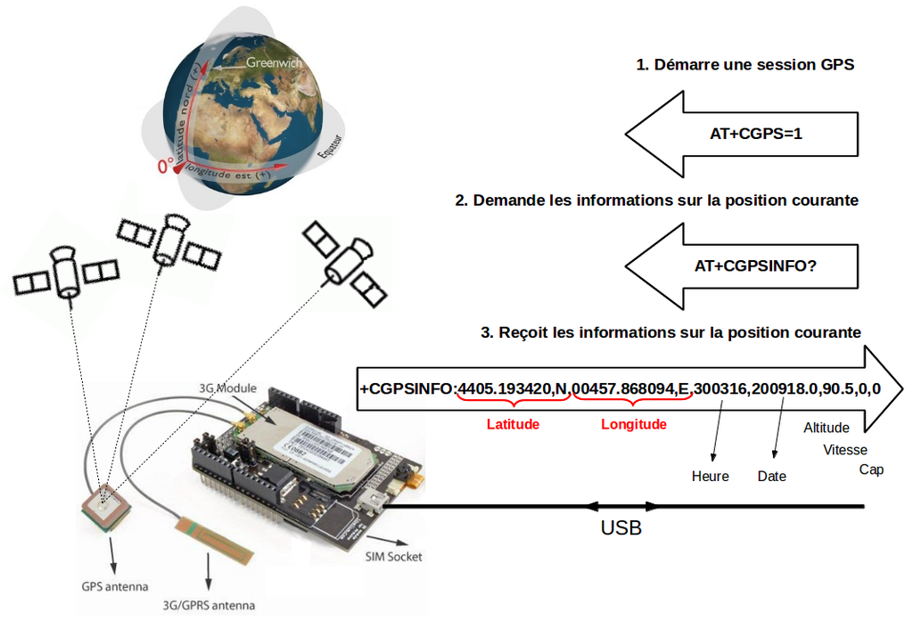

## Communication par modem GPRS/GSM

### Notions de base

Le GPRS (*General Packet Radio Service*) est une norme (protocole réseau) pour la téléphonie mobile dérivée du GSM et complémentaire de celui-ci, permettant un débit de données plus élevé.

Le GPRS est une extension du protocole GSM : il ajoute par rapport à ce dernier la transmission par paquets. Cette méthode est plus adaptée à la transmission des données. En effet, les ressources ne sont allouées que lorsque des données sont échangées, contrairement au mode « circuit » en GSM où un circuit est établi pour toute la durée de la communication. Le GPRS a ensuite évolué au début des années 2000 vers la norme Edge également optimisée pour transférer des données et qui utilise les mêmes antennes et les mêmes fréquences radio.

Le GPRS permet de fournir une connectivité IP constamment disponible à une station mobile (MS), mais les ressources radio sont allouées uniquement quand des données doivent être transférées, ce qui permet une économie de la ressource radio. Les utilisateurs ont donc un accès bon marché, et les opérateurs économisent la ressource radio. De plus, aucun délai de numérotation n’est nécessaire.

### Terminaux GSM/GPRS

Ce moyen de transmission nécessite un terminal disposant d’un modem GSM/GPRS ou 3G/UMTS, ainsi que d’une carte SIM de n’importe quel opérateur avec un forfait “données” (Data) adapté. Le terminal nécessite d’être sous couverture GSM/GPRS pour pouvoir envoyer les données vers la plateforme de traitement. Ce type de terminal est utilisé lorsque l’objet ou la personne à géolocaliser reste dans une zone bien couverte par les réseaux GSM/GPRS.

*Remarque :* Les forfaits GSM/GPRS sont économiquement plus avantageux que les forfaits satellite lorsque l’on souhaite remonter les positions à une fréquence élevée. Ils sont donc à privilégier si les zones où l’équipement se déplace restent bien couvertes par les réseaux GSM/GPRS.

## Travail demandé

Être capable de communiquer avec un modem GPRS/GSM.

## Séquence 1 : commandes AT

On peut tester les commandes AT avec la commande `screen` (`Ctrl-a k` pour sortir), `picocom` (`Ctrl-a Ctrl-x` pour sortir) ou `cutecom`.

# Glossaire

**GSM**

GSM (*Global System for Mobile Communications*) est une norme numérique de seconde génération pour la téléphonie mobile. Elle a été spécifiée et mise au point par l’ETSI (*European Telecommunications Standard Institut*) pour la gamme de fréquences des 900 MHz. Cette norme est particulièrement utilisée en Europe, en Afrique, au Moyen-Orient et en Asie. Tel qu’il a été conçu, le réseau GSM est idéal pour les communications de type « voix » (téléphonie). Le réseau étant commuté, les ressources ne sont allouées que pour la durée de la conversation, comme lors de l’utilisation de lignes téléphoniques fixes. Les clients peuvent soit acheter une carte prépayée, soit souscrire un abonnement.

**GPRS**

GPRS (*General Packet Radio Service*) est une norme (protocole réseau) pour la téléphonie mobile dérivée du GSM et complémentaire de celui-ci, permettant un débit de données plus élevé. On le qualifie souvent de 2,5G ou 2G+. Le G est l’abréviation de génération et le 2,5 indique que c’est une technologie à mi-chemin entre le GSM (deuxième génération) et l’UMTS (troisième génération).

**EDGE**

EDGE (*Enhanced Data Rates for GSM Evolution*) est une norme de téléphonie mobile, une évolution du GPRS qui est elle-même une extension du GSM avec rétrocompatibilité. Le débit maximal descendant a été fixé à 384 kbit/s par l’UIT (Union Internationale des Télécommunication) dans le but de respecter la norme IMT-2000. EDGE est quatre fois plus efficace que le GPRS.

**UMTS**

UMTS (*Universal Mobile Telecommunications System*) est l’une des technologies de téléphonie mobile de troisième génération (3G). Elle est basée sur la technologie W-CDMA, standardisée par le 3GPP et constitue l’implémentation dominante, d’origine européenne, des spécifications IMT-2000 de l’UIT pour les systèmes radio cellulaires 3G. L’UMTS est parfois appelé 3GSM, soulignant la filiation qui a été assurée entre l’UMTS et le standard GSM auquel il succède. Elle est également appelée 3G, pour troisième génération.

**W-CDMA**

Le W-CDMA (*Wideband Code Division Multiple Access*, « multiplexage par code à large bande ») est une technique de codage utilisée dans la partie radio (UTRAN) des réseaux de téléphonie mobile UMTS, de troisième génération.

**HSPA**

HSPA (*High Speed Packet Access*), aussi appelé 3G+ dans sa dénomination commerciale, est la combinaison de deux protocoles utilisés en téléphonie mobile pour améliorer les performances obtenues avec la 3G UMTS : le *High Speed Downlink Packet Access* (HSDPA) et le *High-Speed Uplink Packet Access* (HSUPA). Ils permettent d’atteindre des débits théoriques maximum de 14,4 Mbit/s en descente et 5,8 Mbit/s en montée selon la mise en service de ces deux normes par les opérateurs et la compatibilité du terminal utilisé.

**Carte SIM**

Les téléphones mobiles contiennent une carte SIM qui permet d’identifier l’utilisateur et parfois de stocker un certain nombre de numéros de téléphone. Chaque appareil est identifié, quelle que soit sa marque, par un numéro IMEI que l’on obtient, en entrant sur le clavier, la séquence : *#06#. Il convient de noter ce numéro et de le signaler à son opérateur, en cas de vol, de façon à procéder à son blocage. Cet identifiant ne doit pas être confondu avec l’IMSI contenu dans la carte SIM.

**Code PIN**

Le code PIN est le mot de passe de la carte SIM ; le code PUK permet de débloquer une carte SIM, bloquée après l’introduction de 3 codes PIN erronés. Le code PIN2, s’il existe, est un mot de passe pour un sous-ensemble de fonctions précises de la carte SIM ; le code PUK2 lui est associé, de la même manière.

**Code TMSI**

Sur un réseau cellulaire, un appareil est identifié via un code TMSI (*Temporary Mobile Station Identifier*) dérivé du code IMSI. Grâce à ce système de IMSI/TMSI, un téléphone portable ne voit pas son numéro d’appel divulgué sur le réseau, ce qui permet la confidentialité des appels : comme les TMSI changent souvent et sont alternativement attribués à plusieurs appareils, une personne interceptant le trafic a très peu de chance d’associer un numéro de téléphone à un TMSI.

**Modem**

À lorigine, Le modem (mot-valise, pour modulateur-démodulateur), est un périphérique servant à communiquer avec des utilisateurs distants par l’intermédiaire d’un réseau analogique (comme une ligne téléphonique). Il permet par exemple de se connecter à Internet. Depuis la fin des années 1990, de nombreuses normes de télécommunications sont apparues et, donc autant de nouveaux types de modems : RNIS (ou ISDN), ADSL, GSM, GPRS, Wi-Fi, Wimax …

Retour au sommaire